# Biclusters 04 – comparison

Author

Tim

Published

April 24, 2026

# Introduction

In the following, we analyse the GSEA on biclusters from LEMUR and compare to the reference analysis using cell labels and pseudobulk differential expression analysis using edgeR.

```r
library(dplyr)
library(data.table)
library(SingleCellExperiment)
library(Matrix)
library(lemur)
library(tidyverse)
library(Polychrome)
library(scico)
library(patchwork)
library(pheatmap)
library(fgsea)
library(msigdbr)
library("progressr")

# Choose folders for data and results etc.
folder_data <- "/Users/herbermann/code/data/coculture/"
file_name <- "coculture_effect_in_AML_5000"
wd <- "/Users/herbermann/code/lemur_biclusters"
cache_dir <- file.path(wd, "rds")

set.seed(42)

sce_all <- readRDS(paste0(folder_data, "sce_object_", file_name, ".RDS"))

table_bicluster <- readRDS(file.path(cache_dir, "bicluster_gsea_table.RDS"))
nes_mat <- readRDS(file.path(cache_dir, "bicluster_gsea_nes_mat.RDS"))
table_pseudobulk <- readRDS(file.path(cache_dir, "pseudobulk_gsea_table.RDS"))

# Let us also get all the bicluster details.
filename <- file.path(cache_dir, "fit_nmf.RDS")
nmf_fit <- readRDS(filename)

biclusters <- nmf_fit$biclusters
null_h <- nmf_fit$null_h
null_w_pos <- nmf_fit$null_w_pos
null_w_neg <- nmf_fit$null_w_neg

W <- biclusters@w
H <- biclusters@h

n_genes <- nrow(W)/2
W_pos <- W[1:n_genes, ]
W_neg  <- W[(n_genes+1):nrow(W), ]

fit <- readRDS(file.path(cache_dir, "lemur_essi_fit.rds"))
de_matrix <- as.matrix(assay(fit$training_data, "DE"))

rownames(W_pos) <- rownames(de_matrix)
rownames(W_neg) <- rownames(de_matrix)

# Getting cell level labels and label bicluster members
celltype_map <- setNames(sce_all$clusters_renamed, colnames(sce_all))
patient_map <- setNames(sce_all$individual, colnames(sce_all))



# Make all assignments of cell membership to biclusters
null_h <- null_h[3,]
null_w_pos <- null_w_pos[3,]
null_w_neg <- null_w_neg[3,]

n_bic <- nrow(H)

bic_cells <- lapply(1:n_bic, function(i){
  H[i,] > null_h[i]
})

bic_up <- lapply(1:n_bic, function(i){
  W_pos[,i] > null_w_pos[i]
})

bic_down <- lapply(1:n_bic, function(i){
  W_neg[,i] > null_w_neg[i]
})

bic_genes <- Map(function(up, down) up | down, bic_up, bic_down)
```

# Comparisons

## Bicluster overlap

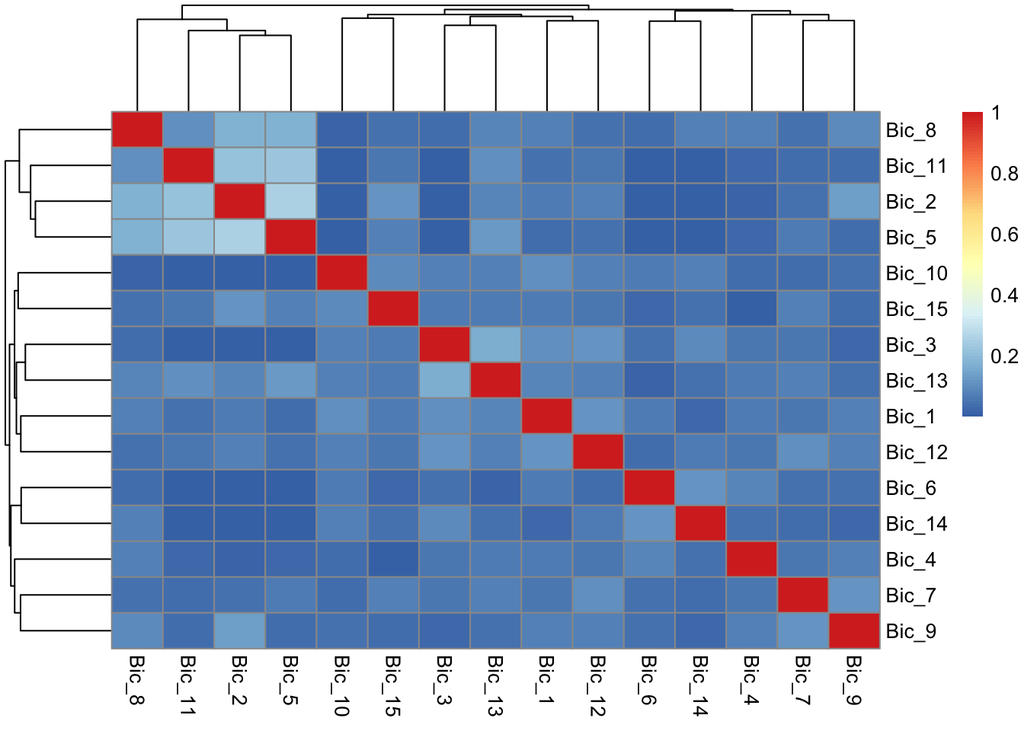

```r
jaccard_with_logic <- function(A, B) {
  stopifnot(length(A) == length(B))
  denom <- sum(A | B)
  if (denom == 0) return(NA_real_)
  sum(A & B) / denom
}

n_bic <- length(bic_cells)

jaccard_cells <- matrix(
  NA_real_,
  nrow = n_bic,
  ncol = n_bic,
  dimnames = list(paste0("Bic_", seq_len(n_bic)),
                  paste0("Bic_", seq_len(n_bic)))
)

for (i in seq_len(n_bic)) {
  for (j in seq_len(n_bic)) {
    jaccard_cells[i, j] <- jaccard_with_logic(bic_cells[[i]], bic_cells[[j]])
  }
}

n_bic <- length(bic_genes)

jaccard_genes <- matrix(
  NA_real_,
  nrow = n_bic,
  ncol = n_bic,
  dimnames = list(paste0("Bic_", seq_len(n_bic)),
                  paste0("Bic_", seq_len(n_bic)))
)

for (i in seq_len(n_bic)) {
  for (j in seq_len(n_bic)) {
    jaccard_genes[i, j] <- jaccard_with_logic(bic_genes[[i]], bic_genes[[j]])
  }
}


pheatmap(jaccard_cells)
```

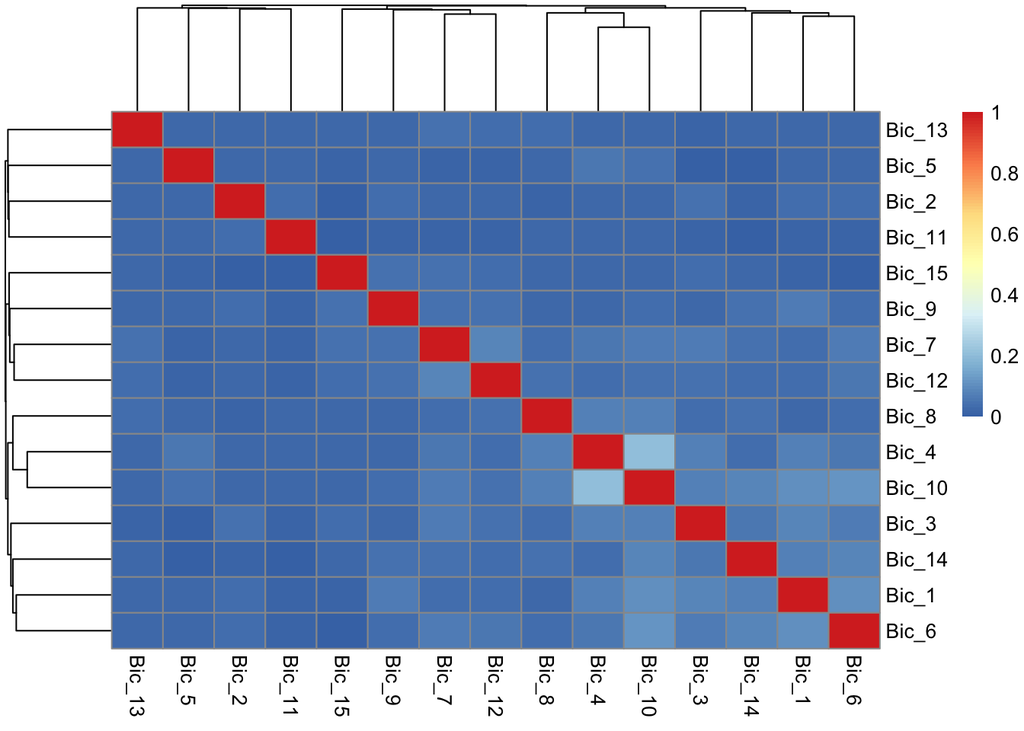

```r
pheatmap(jaccard_genes)
```

## Bicluster composition

First, how do known annotations and labels distribute over biclusters?

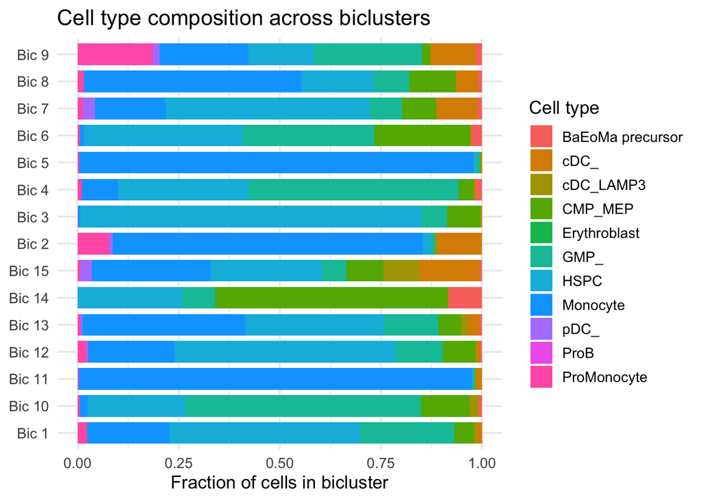

```r
#Investigate connection of biclusters to known annotations
# --- align all objects to the same cells ---
common_cells <- Reduce(intersect, c(
  list(names(celltype_map), names(patient_map)),
  lapply(bic_cells, names)
))

celltype_map2 <- celltype_map[common_cells]
patient_map2   <- patient_map[common_cells]
bic_cells2     <- lapply(bic_cells, function(x) x[common_cells])

# --- cell type composition within each bicluster ---
bic_celltypes <- lapply(seq_along(bic_cells2), function(i) {
  celltype_map2[bic_cells2[[i]]]
})

plot_df <- bind_rows(lapply(seq_along(bic_celltypes), function(i) {
  ct <- bic_celltypes[[i]]

  df <- as.data.frame(table(ct))
  colnames(df) <- c("celltype", "n")
  df$bic <- paste0("Bic ", i)
  df
})) %>%
  filter(!is.na(celltype)) %>%
  group_by(bic) %>%
  mutate(prop = n / sum(n)) %>%
  ungroup()

ggplot(plot_df, aes(x = bic, y = prop, fill = celltype)) +
  geom_col(width = 0.8) +
  coord_flip() +
  labs(
    x = NULL,
    y = "Fraction of cells in bicluster",
    fill = "Cell type",
    title = "Cell type composition across biclusters"
  ) +
  theme_minimal(base_size = 13)
```

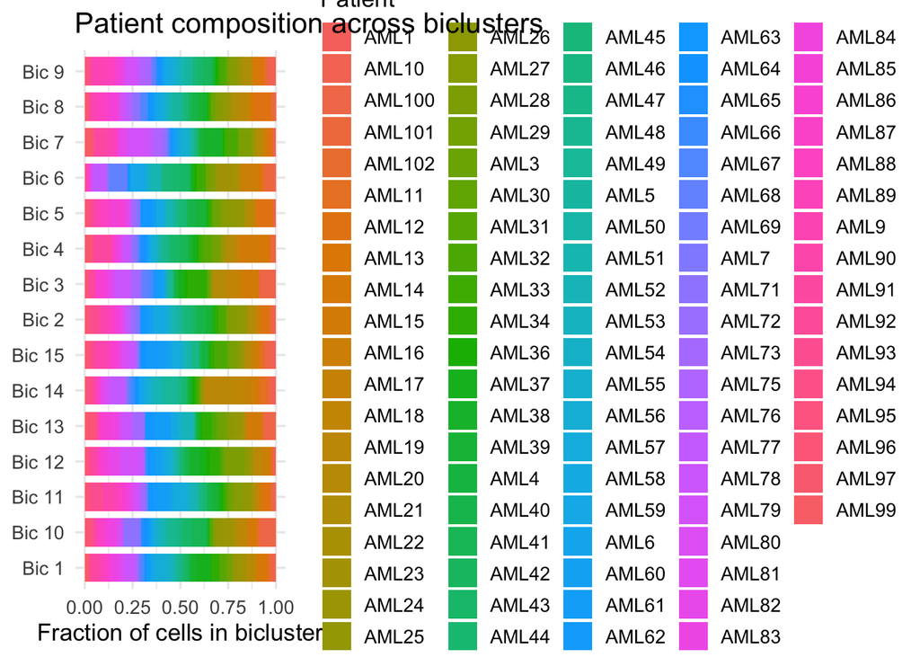

```r
# --- optional: patient composition within each bicluster ---
bic_patient <- lapply(seq_along(bic_cells2), function(i) {
  patient_map2[bic_cells2[[i]]]
})

plot_df_patient <- bind_rows(lapply(seq_along(bic_patient), function(i) {
  df <- as.data.frame(table(patient = bic_patient[[i]]))
  colnames(df) <- c("patient", "n")
  df$bic <- paste0("Bic ", i)
  df
})) %>%
  filter(!is.na(patient)) %>%
  group_by(bic) %>%
  mutate(prop = n / sum(n)) %>%
  ungroup()

ggplot(plot_df_patient, aes(x = bic, y = prop, fill = patient)) +
  geom_col(width = 0.8) +
  coord_flip() +
  labs(
    x = NULL,
    y = "Fraction of cells in bicluster",
    fill = "Patient",
    title = "Patient composition across biclusters"
  ) +
  theme_minimal(base_size = 13)
```

While biclusters vary in cell- and patient composition, there is no strong association of certain biclusterspatient labels. This might be encouraging, as biclusters do identify gene programmes, and therefore, these appear to be programmes orthogonal to patients. A stronger association with cell types is expected in that case.

On a related note, we check how a given cell label is made up from which biclusters. Note that this does not have to add up to 1, as a cell can belong to multiple biclusters.

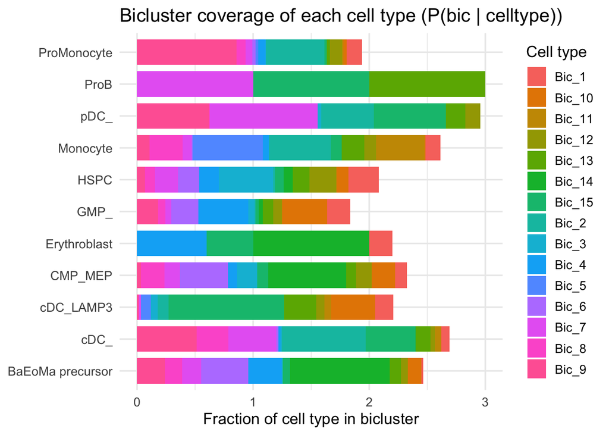

```r
# --- bicluster composition within each cell type ---
celltypes <- levels(celltype_map2)

celltype_to_bic <- lapply(celltypes, function(ct) {
  ct_vec <- celltype_map2 == ct

  sapply(bic_cells2, function(bic_vec) {
    sum(bic_vec & ct_vec) / sum(ct_vec)
  })
})

celltype_to_bic <- do.call(cbind, celltype_to_bic)
colnames(celltype_to_bic) <- celltypes
rownames(celltype_to_bic) <- paste0("Bic_", seq_along(bic_cells2))

celltype_to_bic <- t(celltype_to_bic)

plot_df <- as.data.frame(celltype_to_bic)
plot_df$bic <- rownames(plot_df)

plot_df_long <- pivot_longer(
  plot_df,
  cols = -bic,
  names_to = "celltype",
  values_to = "prop"
)

ggplot(plot_df_long, aes(x = bic, y = prop, fill = celltype)) +
  geom_col(width = 0.8) +
  coord_flip() +
  labs(
    x = NULL,
    y = "Fraction of cell type in bicluster",
    fill = "Cell type",
    title = "Bicluster coverage of each cell type (P(bic | celltype))"
  ) +
  theme_minimal(base_size = 13)
```

We may also investigate Jaccard overlaps between biclusters and cell types, revealing potentially strong association of cell types and biclusters.

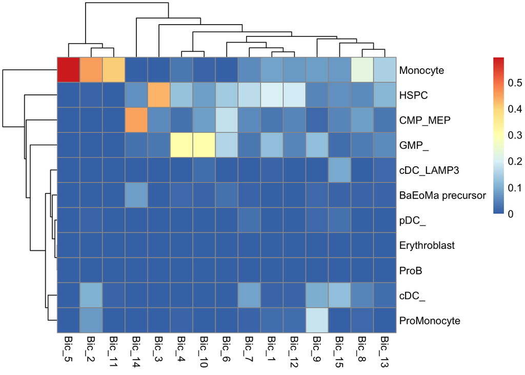

```r
jaccard_with_logic <- function(A, B) {
  stopifnot(length(A) == length(B))
  denom <- sum(A | B)
  if (denom == 0) return(NA_real_)
  sum(A & B) / denom
}

# make sure both are aligned to the same cells
common_cells <- intersect(names(celltype_map), names(bic_cells[[1]]))
celltype_map2 <- celltype_map[common_cells]
bic_cells2 <- lapply(bic_cells, function(x) x[common_cells])

celltypes <- levels(celltype_map2)

jaccard_matrix <- sapply(bic_cells2, function(bic_vec) {
  sapply(celltypes, function(ct) {
    ct_vec <- celltype_map2 == ct
    jaccard_with_logic(bic_vec, ct_vec)
  })
})

# nice labels
rownames(jaccard_matrix) <- celltypes
colnames(jaccard_matrix) <- paste0("Bic_", seq_along(bic_cells2))

pheatmap(jaccard_matrix)
```

# Keep it simple

To tame the programmes (appearing often in multiple biclusters) over biclusters, we take a matrix of (pathways, biclusters) and PCA it to find the main axis of variation

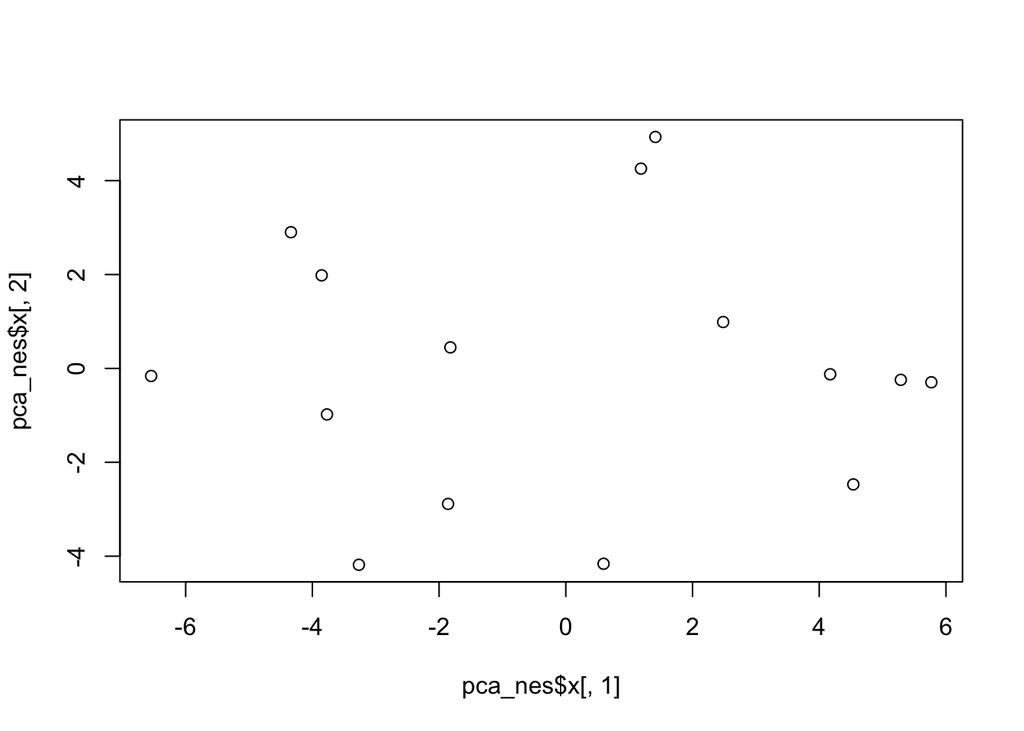

```r
pca_nes <- prcomp(nes_mat,center = TRUE, scale. = TRUE)
plot(pca_nes$x[,1], pca_nes$x[,2])
```

```r
summary(pca_nes)
```

```
Importance of components:
                          PC1    PC2    PC3    PC4     PC5     PC6     PC7
Standard deviation     3.9398 2.7559 2.4405 2.2428 1.81839 1.72064 1.62799
Proportion of Variance 0.3104 0.1519 0.1191 0.1006 0.06613 0.05921 0.05301
Cumulative Proportion  0.3104 0.4623 0.5815 0.6821 0.74819 0.80740 0.86041
                           PC8     PC9    PC10    PC11    PC12   PC13    PC14
Standard deviation     1.23946 1.15623 1.07403 0.96909 0.90442 0.8573 0.67895
Proportion of Variance 0.03073 0.02674 0.02307 0.01878 0.01636 0.0147 0.00922
Cumulative Proportion  0.89113 0.91787 0.94094 0.95972 0.97608 0.9908 1.00000
                            PC15
Standard deviation     3.986e-16
Proportion of Variance 0.000e+00
Cumulative Proportion  1.000e+00
```

We see most variation is captured by PC1-PC4 (around 70%), and perhaps some moderate contribtuion also from PC5-PC7. Those should correspond to interpretable combinations of programmes enriched over combinations of biclusters

```r
pc1 <- pca_nes$rotation[,1]
pc1_pos <- paste(capture.output(head(sort(pc1, decreasing = TRUE), 12)), collapse = "<br>")
pc1_neg <- paste(capture.output(head(sort(pc1), 12)), collapse = "<br>")

pc2 <- pca_nes$rotation[,2]
pc2_pos <- paste(capture.output(head(sort(pc2, decreasing = TRUE), 12)), collapse = "<br>")
pc2_neg <- paste(capture.output(head(sort(pc2), 12)), collapse = "<br>")

pc3 <- pca_nes$rotation[,3]
pc3_pos <- paste(capture.output(head(sort(pc3, decreasing = TRUE), 12)), collapse = "<br>")
pc3_neg <- paste(capture.output(head(sort(pc3), 12)), collapse = "<br>")

pc4 <- pca_nes$rotation[,4]
pc4_pos <- paste(capture.output(head(sort(pc4, decreasing = TRUE), 12)), collapse = "<br>")
pc4_neg <- paste(capture.output(head(sort(pc4), 12)), collapse = "<br>")
```

Asking chatGPT because I do not know any biology:

#### PC1

**NEGATIVE LOADINGS** (neg. NES): Differentiated, structural, lineage-associated cells

#### PC2

**POSITIVE LOADING** (pos. NES): metabolic / biosynthetic / maintenance state

**NEGATIVE LOADINGS** (neg. NES): signaling / structural / functional communication state

#### PC3

**POSITIVE LOADING** (pos. NES): signaling / stress / transition **NEGATIVE LOADINGS** (neg. NES): metabolically specialized / functional

#### PC4

**POSITIVE LOADING** (pos. NES): immune-driven, cytokine signaling–dominant state **NEGATIVE LOADINGS** (neg. NES): growth / metabolic / structural state

# In depth (this is an awful lot of programmes)

## Monocytes and BIC 2, 5, 11

Biclusters 2, 5, and 11 are mostly made up from Monocytes, especially 5 and 11. We can check results of GSEA on BIC 5 and 11 as well as Monocytes pseudobulk to assess what overlap and what new information LEMUR + biclustering reveals.

```r
bic2_cells  <- names(bic_cells[[2]])[bic_cells[[2]]]
bic5_cells  <- names(bic_cells[[5]])[bic_cells[[5]]]
bic11_cells <- names(bic_cells[[11]])[bic_cells[[11]]]

mono_cells <- names(celltype_map)[celltype_map == "Monocyte"]

mono_pathways <- table_pseudobulk |> filter(cell_type == "Monocyte") |>
    select(cell_type, pathway, NES, padj)

bic2_pathways <- table_bicluster |> filter(bicluster == 2) |>
    select(bicluster, pathway, NES, padj)
bic5_pathways <- table_bicluster |> filter(bicluster == 5) |>
    select(bicluster, pathway, NES, padj)
bic11_pathways <- table_bicluster |> filter(bicluster == 11) |>
    select(bicluster, pathway, NES, padj)

print("----BIC2----")
```

```
[1] "----BIC2----"
```

```r
print(bic2_pathways)
```

```
[1] bicluster pathway   NES       padj
<0 rows> (or 0-length row.names)
```

```r
print("----BIC5----")
```

```
[1] "----BIC5----"
```

```r
print(bic5_pathways)
```

```
  bicluster                                    pathway       NES         padj
1         5 HALLMARK_EPITHELIAL_MESENCHYMAL_TRANSITION -1.874541 0.0023312705
2         5         HALLMARK_INTERFERON_GAMMA_RESPONSE  1.896843 0.0004834624
3         5                    HALLMARK_MYC_TARGETS_V1  1.766230 0.0354141207
```

```r
print("----BIC11---")
```

```
[1] "----BIC11---"
```

```r
print(bic11_pathways)
```

```
  bicluster                            pathway       NES         padj
1        11              HALLMARK_ADIPOGENESIS -1.712049 0.0445900420
2        11 HALLMARK_INTERFERON_GAMMA_RESPONSE  1.797974 0.0005749869
3        11            HALLMARK_MYC_TARGETS_V1  1.752349 0.0211294105
4        11   HALLMARK_TNFA_SIGNALING_VIA_NFKB  1.799830 0.0005749869
```

```r
print("----MONO----")
```

```
[1] "----MONO----"
```

```r
print(mono_pathways)
```

```
           cell_type                            pathway      NES        padj
Monocyte.1  Monocyte HALLMARK_INTERFERON_GAMMA_RESPONSE 2.877119 0.001593761
Monocyte.2  Monocyte HALLMARK_INTERFERON_ALPHA_RESPONSE 2.630477 0.001593761
Monocyte.3  Monocyte   HALLMARK_TNFA_SIGNALING_VIA_NFKB 2.013505 0.001593761
Monocyte.4  Monocyte       HALLMARK_ALLOGRAFT_REJECTION 1.940079 0.001593761
Monocyte.5  Monocyte     HALLMARK_INFLAMMATORY_RESPONSE 1.873752 0.001593761
Monocyte.6  Monocyte   HALLMARK_IL6_JAK_STAT3_SIGNALING 1.819981 0.001593761
Monocyte.7  Monocyte                HALLMARK_COMPLEMENT 1.558951 0.025301751
```

Not entirely sure how to interpret this but…

- Monocytes appear to be showing interferon/inflammatory programmes
- So do BIC 5 and 11, however there is a secondary programme
  - BIC 5 something epithelial
  - BIC 11 some sort of metabolic activation
- We found different cell states within a label!

## HSPC & BIC 1, 3, 6, 7, 12

These bicluster are made up of large fractions of HSPC. Let us compare those to HSPC pseudobulk GSEA.

```r
bic1_cells  <- names(bic_cells[[1]])[bic_cells[[1]]]
bic3_cells  <- names(bic_cells[[3]])[bic_cells[[3]]]
bic6_cells <- names(bic_cells[[6]])[bic_cells[[6]]]
bic7_cells <- names(bic_cells[[7]])[bic_cells[[7]]]
bic12_cells <- names(bic_cells[[12]])[bic_cells[[12]]]

hspc_cells <- names(celltype_map)[celltype_map == "HSPC"]

hspc_pathways <- table_pseudobulk |> filter(cell_type == "HSPC") |>
    select(cell_type, pathway, NES, padj)

bic1_pathways <- table_bicluster |> filter(bicluster == 1) |>
    select(bicluster, pathway, NES, padj)
bic3_pathways <- table_bicluster |> filter(bicluster == 3) |>
    select(bicluster, pathway, NES, padj)
bic6_pathways <- table_bicluster |> filter(bicluster == 6) |>
    select(bicluster, pathway, NES, padj)
bic7_pathways <- table_bicluster |> filter(bicluster == 7) |>
    select(bicluster, pathway, NES, padj)
bic12_pathways <- table_bicluster |> filter(bicluster == 12) |>
    select(bicluster, pathway, NES, padj)

print("----BIC1----")
```

```
[1] "----BIC1----"
```

```r
print(bic1_pathways)
```

```
  bicluster                  pathway       NES       padj
1         1 HALLMARK_HEME_METABOLISM  1.743785 0.03244477
2         1  HALLMARK_MYC_TARGETS_V1 -1.913164 0.01350995
```

```r
print("----BIC3----")
```

```
[1] "----BIC3----"
```

```r
print(bic3_pathways)
```

```
[1] bicluster pathway   NES       padj
<0 rows> (or 0-length row.names)
```

```r
print("----BIC6---")
```

```
[1] "----BIC6---"
```

```r
print(bic6_pathways)
```

```
  bicluster                            pathway       NES        padj
1         6   HALLMARK_CHOLESTEROL_HOMEOSTASIS  1.792344 0.039543390
2         6           HALLMARK_HEME_METABOLISM  1.686795 0.039543390
3         6 HALLMARK_INTERFERON_GAMMA_RESPONSE -1.729757 0.005278255
```

```r
print("----BIC7---")
```

```
[1] "----BIC7---"
```

```r
print(bic7_pathways)
```

```
  bicluster                            pathway      NES         padj
1         7   HALLMARK_CHOLESTEROL_HOMEOSTASIS 1.988076 0.0043972354
2         7 HALLMARK_INTERFERON_ALPHA_RESPONSE 1.867852 0.0062077619
3         7          HALLMARK_MTORC1_SIGNALING 1.744303 0.0102699614
4         7            HALLMARK_MYC_TARGETS_V1 2.189573 0.0001091023
5         7            HALLMARK_MYC_TARGETS_V2 1.899740 0.0240560680
```

```r
print("----BIC12---")
```

```
[1] "----BIC12---"
```

```r
print(bic12_pathways)
```

```
  bicluster                            pathway       NES         padj
1        12   HALLMARK_CHOLESTEROL_HOMEOSTASIS -1.736030 0.0370177431
2        12          HALLMARK_MTORC1_SIGNALING -2.020229 0.0001682705
3        12            HALLMARK_MYC_TARGETS_V1 -2.029208 0.0008879754
4        12 HALLMARK_UNFOLDED_PROTEIN_RESPONSE -1.932805 0.0068442440
```

```r
print("----HSPC----")
```

```
[1] "----HSPC----"
```

```r
print(hspc_pathways)
```

```
        cell_type                            pathway      NES        padj
HSPC.1       HSPC HALLMARK_INTERFERON_GAMMA_RESPONSE 2.815834 0.001119607
HSPC.2       HSPC HALLMARK_INTERFERON_ALPHA_RESPONSE 2.577551 0.001119607
HSPC.3       HSPC   HALLMARK_TNFA_SIGNALING_VIA_NFKB 2.317585 0.001119607
HSPC.4       HSPC     HALLMARK_INFLAMMATORY_RESPONSE 2.224026 0.001119607
HSPC.5       HSPC       HALLMARK_ALLOGRAFT_REJECTION 2.141960 0.001119607
HSPC.6       HSPC   HALLMARK_IL6_JAK_STAT3_SIGNALING 1.957362 0.001119607
HSPC.7       HSPC                HALLMARK_COMPLEMENT 1.891413 0.001119607
HSPC.8       HSPC       HALLMARK_IL2_STAT5_SIGNALING 1.584493 0.005192988
HSPC.9       HSPC   HALLMARK_CHOLESTEROL_HOMEOSTASIS 1.716568 0.010630478
HSPC.10      HSPC            HALLMARK_UV_RESPONSE_UP 1.638441 0.010749877
HSPC.11      HSPC HALLMARK_UNFOLDED_PROTEIN_RESPONSE 1.699053 0.013389466
```

```r
#bic6_cells <- bic_cells[["BIC6"]]   # or bic_cells[[6]]
hspc_cells <- celltype_map == "HSPC"

cell_ids <- colnames(de_matrix)

hspc_cells <- celltype_map[cell_ids] == "HSPC"
bic6_idx   <- cell_ids %in% bic6_cells

target_idx <- which(bic6_idx & hspc_cells)
background_idx <- which(hspc_cells & !bic6_idx)

score_bicluster_custom <- function(de_matrix, in_idx, out_idx, eps = 1e-8) {
  x_in  <- de_matrix[, in_idx, drop = FALSE]
  x_out <- de_matrix[, out_idx, drop = FALSE]

  score <- rowMeans(x_in, na.rm = TRUE) - rowMeans(x_out, na.rm = TRUE)

  s_in  <- matrixStats::rowSds(as.matrix(x_in), na.rm = TRUE)
  s_out <- matrixStats::rowSds(as.matrix(x_out), na.rm = TRUE)
  pooled <- sqrt((s_in^2 + s_out^2) / 2)

  score <- score / (pooled + eps)
  sort(score, decreasing = TRUE)
}

scores <- score_bicluster_custom(
  de_matrix,
  in_idx  = target_idx,
  out_idx = background_idx
)

msig <- msigdbr(species = "Homo sapiens", category = "H")
pathways <- split(msig$gene_symbol, msig$gs_name)

res <- fgsea(pathways = pathways, stats = scores)
res <- res[order(res$padj), ]
head(res, 10)
```

```
                               pathway        pval       padj   log2err
                                <char>       <num>      <num>     <num>
 1: HALLMARK_INTERFERON_GAMMA_RESPONSE 0.001079957 0.05399783 0.4550599
 2:           HALLMARK_HEME_METABOLISM 0.007455198 0.10409679 0.4070179
 3: HALLMARK_INTERFERON_ALPHA_RESPONSE 0.008327743 0.10409679 0.3807304
 4:           HALLMARK_MITOTIC_SPINDLE 0.007838367 0.10409679 0.3807304
 5: HALLMARK_OXIDATIVE_PHOSPHORYLATION 0.039136898 0.32614082 0.3217759
 6:         HALLMARK_PROTEIN_SECRETION 0.034285121 0.32614082 0.3217759
 7:         HALLMARK_ANDROGEN_RESPONSE 0.104234528 0.52561445 0.1752040
 8:   HALLMARK_CHOLESTEROL_HOMEOSTASIS 0.115635179 0.52561445 0.1656567
 9:          HALLMARK_MTORC1_SIGNALING 0.112927192 0.52561445 0.1596467
10:       HALLMARK_PANCREAS_BETA_CELLS 0.100352113 0.52561445 0.1864326
            ES       NES  size                                leadingEdge
         <num>     <num> <int>                                     <list>
 1: -0.3309729 -1.641280   132   LAP3,GBP4,FCGR1A,SSPN,NFKB1,FGL2,...[52]
 2:  0.4047189  1.587842    64  TENT5C,TAL1,DMTN,FN3K,TRIM58,CPOX,...[27]
 3: -0.3642266 -1.577761    64 GBP2,LAP3,GBP4,IFI44L,RIPK2,TRAFD1,...[29]
 4:  0.3737661  1.539264    82 KATNB1,WASF1,VCL,SASS6,MYH10,KIF11,...[27]
 5: -0.4502010 -1.516741    23           ACAT1,TIMM10,VDAC1,POR,LDHB,FDX1
 6:  0.5322770  1.533138    17    CD63,STAM,ANP32E,GALC,IGF2R,CAV2,...[8]
 7:  0.3726600  1.326161    39  FADS1,DHCR24,INPP4B,IDI1,HPGD,GSR,...[19]
 8:  0.3678871  1.301574    38      EBP,TM7SF2,LDLR,CLU,IDI1,FASN,...[17]
 9:  0.2952766  1.254713   100  G6PD,EBP,TM7SF2,FADS1,LDLR,DHCR24,...[23]
10:  0.7341205  1.386506     4                                 AKT3,FOXO1
```

```r
library(scater)
library(scran)
library(igraph)

sce <- fit$training_data
hspc_sce <- sce[, sce$colData$clusters_renamed == "HSPC"]


if (!"logcounts" %in% assayNames(hspc_sce)) {
  hspc_sce <- logNormCounts(hspc_sce)
}

set.seed(1)
hspc_sce <- runPCA(hspc_sce, ncomponents = 20)

g <- buildSNNGraph(hspc_sce, use.dimred = "PCA", k = 20)
cl <- cluster_louvain(g)

cd <- colData(hspc_sce)
cd[["hspc_cluster"]] <- factor(cl$membership)
colData(hspc_sce) <- cd

bic6_in_hspc <- colnames(hspc_sce) %in% bic6_cells

tab <- table(
  cluster = colData(hspc_sce)[["hspc_cluster"]],
  bic6    = bic6_in_hspc
)
tab
```

```
       bic6
cluster FALSE TRUE
     1    391   10
     2    566  223
     3    387    4
     4    364   78
     5    366    9
     6    248  912
     7    258    0
     8    308    0
     9    835   29
     10    67  894
     11   842    0
     12   688   30
     13   630    5
     14   482    1
     15   412   28
     16   102   10
     17   368    1
     18   771   12
     19   293    0
     20   534   12
     21   262    0
     22   257   22
     23   212    0
     24   182    0
     25   498    0
     26   199    0
```

```r
prop.table(tab, 1)
```

```
       bic6
cluster       FALSE        TRUE
     1  0.975062344 0.024937656
     2  0.717363752 0.282636248
     3  0.989769821 0.010230179
     4  0.823529412 0.176470588
     5  0.976000000 0.024000000
     6  0.213793103 0.786206897
     7  1.000000000 0.000000000
     8  1.000000000 0.000000000
     9  0.966435185 0.033564815
     10 0.069719043 0.930280957
     11 1.000000000 0.000000000
     12 0.958217270 0.041782730
     13 0.992125984 0.007874016
     14 0.997929607 0.002070393
     15 0.936363636 0.063636364
     16 0.910714286 0.089285714
     17 0.997289973 0.002710027
     18 0.984674330 0.015325670
     19 1.000000000 0.000000000
     20 0.978021978 0.021978022
     21 1.000000000 0.000000000
     22 0.921146953 0.078853047
     23 1.000000000 0.000000000
     24 1.000000000 0.000000000
     25 1.000000000 0.000000000
     26 1.000000000 0.000000000
```

```r
library(fgsea)
library(msigdbr)
library(dplyr)

## ------------------------------------------------------------
## 1) HSPC-only object and aligned cell IDs
## ------------------------------------------------------------
# HSPC subset
sce <- fit$training_data
hspc_idx <- colData(sce)[["clusters_renamed"]] == "HSPC"
hspc_sce <- sce[, hspc_idx]

# cell IDs for this subset
cell_ids <- colnames(hspc_sce)

# cluster labels for this subset
clusters <- colData(hspc_sce)[["hspc_cluster"]]

## hspc_sce is already the HSPC subset

## cluster membership from the graph clustering
cluster_membership <- cl$membership

## sanity check
length(cluster_membership)
```

```
[1] 12802
```

```r
ncol(hspc_sce)
```

```
[1] 12802
```

```r
## cluster 10 inside HSPCs
cluster10_idx <- as.integer(cluster_membership) == 10

## BIC6 inside HSPCs
bic6_idx <- colnames(hspc_sce) %in% bic6_cells

## checks
stopifnot(length(cluster10_idx) == ncol(hspc_sce))
stopifnot(length(bic6_idx) == ncol(hspc_sce))

## ------------------------------------------------------------
## 2) Pathway database
## ------------------------------------------------------------
msig <- msigdbr(species = "Homo sapiens", category = "H")
pathways <- split(msig$gene_symbol, msig$gs_name)

## ------------------------------------------------------------
## 3) Generic scoring function
## ------------------------------------------------------------
score_group_vs_rest <- function(de_matrix, in_idx, out_idx, eps = 1e-8) {
  stopifnot(ncol(de_matrix) == length(in_idx))
  stopifnot(ncol(de_matrix) == length(out_idx))

  x_in  <- de_matrix[, in_idx, drop = FALSE]
  x_out <- de_matrix[, out_idx, drop = FALSE]

  score <- rowMeans(x_in, na.rm = TRUE) - rowMeans(x_out, na.rm = TRUE)

  s_in  <- matrixStats::rowSds(as.matrix(x_in), na.rm = TRUE)
  s_out <- matrixStats::rowSds(as.matrix(x_out), na.rm = TRUE)
  pooled <- sqrt((s_in^2 + s_out^2) / 2)

  score <- score / (pooled + eps)
  sort(score, decreasing = TRUE)
}

## ------------------------------------------------------------
## 4) Define contrasts
## ------------------------------------------------------------
expr <- assay(hspc_sce, "logcounts")

cluster10_scores <- score_group_vs_rest(
  de_matrix = expr,
  in_idx = cluster10_idx,
  out_idx = !cluster10_idx
)

bic6_scores <- score_group_vs_rest(
  de_matrix = expr,
  in_idx = bic6_idx,
  out_idx = !bic6_idx
)

## ------------------------------------------------------------
## 5) GSEA
## ------------------------------------------------------------
res_cluster10 <- fgsea(pathways = pathways, stats = cluster10_scores)
res_cluster10 <- res_cluster10[order(res_cluster10$padj), ]

res_bic6 <- fgsea(pathways = pathways, stats = bic6_scores)
res_bic6 <- res_bic6[order(res_bic6$padj), ]

head(res_cluster10, 10)
```

```
                               pathway         pval         padj   log2err
                                <char>        <num>        <num>     <num>
 1:               HALLMARK_E2F_TARGETS 2.823818e-11 7.059545e-10 0.8634154
 2:            HALLMARK_MYC_TARGETS_V1 1.823369e-11 7.059545e-10 0.8634154
 3: HALLMARK_INTERFERON_ALPHA_RESPONSE 2.224184e-07 3.706974e-06 0.6901325
 4: HALLMARK_INTERFERON_GAMMA_RESPONSE 2.356384e-06 2.945480e-05 0.6272567
 5:            HALLMARK_G2M_CHECKPOINT 4.149113e-06 4.086751e-05 0.6105269
 6:            HALLMARK_MYC_TARGETS_V2 4.904101e-06 4.086751e-05 0.6105269
 7:           HALLMARK_APICAL_JUNCTION 1.551988e-03 1.108563e-02 0.4550599
 8:          HALLMARK_MTORC1_SIGNALING 2.343737e-03 1.464836e-02 0.4317077
 9:   HALLMARK_TNFA_SIGNALING_VIA_NFKB 4.018325e-03 2.232403e-02 0.4070179
10: HALLMARK_OXIDATIVE_PHOSPHORYLATION 4.988277e-03 2.494138e-02 0.4070179
            ES       NES  size                                   leadingEdge
         <num>     <num> <int>                                        <list>
 1:  0.5758427  2.337491   139        SMC4,NME1,RAN,MYC,DCTPP1,POLD2,...[72]
 2:  0.7356061  2.518206    52          NME1,RAN,MYC,POLD2,SRM,VDAC1,...[40]
 3: -0.5964704 -2.244541    64  GBP2,IFITM1,IFI44L,IFITM3,GBP4,ISG20,...[42]
 4: -0.4567229 -1.934441   132 VAMP5,IFI44L,IFITM3,GBP4,ISG20,IL10RA,...[71]
 5:  0.4974518  1.955512   113       SMC4,MYC,SFPQ,HMGA1,CKS2,NUSAP1,...[43]
 6:  0.7723053  2.238303    23     MAP3K6,MYC,DCTPP1,SRM,HSPE1,PA2G4,...[17]
 7: -0.4605733 -1.726675    62         CD34,AKT3,NRXN2,JUP,EVL,GNAI1,...[30]
 8:  0.4306997  1.657871   100      ATP5MC1,TPI1,XBP1,PRDX1,PPA1,PNP,...[38]
 9: -0.3495121 -1.514042   149  CXCL11,ID2,CDKN1A,IFIT2,CXCL10,CEBPD,...[44]
10:  0.6117790  1.773064    23 ATP5MC1,LDHB,VDAC1,ATP5MC3,CYCS,ALAS1,...[13]
```

```r
head(res_bic6, 10)
```

```
                               pathway         pval         padj   log2err
                                <char>        <num>        <num>     <num>
 1: HALLMARK_INTERFERON_ALPHA_RESPONSE 1.694122e-18 8.470609e-17 1.1146645
 2: HALLMARK_INTERFERON_GAMMA_RESPONSE 7.527534e-17 1.881883e-15 1.0574636
 3:            HALLMARK_MYC_TARGETS_V1 3.071265e-07 5.118776e-06 0.6749629
 4:               HALLMARK_E2F_TARGETS 5.738171e-06 7.172714e-05 0.6105269
 5:            HALLMARK_MYC_TARGETS_V2 8.232947e-06 8.232947e-05 0.5933255
 6:   HALLMARK_TNFA_SIGNALING_VIA_NFKB 2.217741e-04 1.848117e-03 0.5188481
 7:     HALLMARK_INFLAMMATORY_RESPONSE 1.144310e-03 8.173641e-03 0.4550599
 8:               HALLMARK_COAGULATION 2.055331e-03 1.284582e-02 0.4317077
 9:           HALLMARK_APICAL_JUNCTION 4.131306e-03 2.148540e-02 0.4070179
10:        HALLMARK_TGF_BETA_SIGNALING 4.297080e-03 2.148540e-02 0.4070179
            ES       NES  size                                 leadingEdge
         <num>     <num> <int>                                      <list>
 1: -0.7921030 -2.707759    64 GBP2,IFITM1,GBP4,IFI44L,IRF7,IFITM3,...[47]
 2: -0.6521748 -2.508209   132   GBP4,IFI44L,IRF7,IFITM3,MX1,ISG20,...[91]
 3:  0.6487442  2.338901    52       IMPDH2,NME1,MYC,RAN,SRM,POLD2,...[32]
 4:  0.4534512  1.906038   139       SMC4,NME1,MYC,RAN,HMGA1,POLD2,...[59]
 5:  0.7497445  2.219433    23    MAP3K6,MYC,SRM,DCTPP1,IPO4,HSPE1,...[17]
 6: -0.4285063 -1.676319   149 IRF1,CXCL11,IFIT2,ID2,CXCL10,CDKN1A,...[68]
 7: -0.4194977 -1.595239   120 IFITM1,IRF7,IRF1,CD48,CXCL11,CXCL10,...[51]
 8:  0.4616625  1.693596    59    APOC2,CFD,CLU,C2,SERPINA1,S100A1,...[10]
 9: -0.4797563 -1.635446    62       CD34,AKT3,JUP,EVL,NRXN2,GNAI1,...[30]
10: -0.5993438 -1.677592    24       ID2,SMAD1,ENG,SMAD3,ID3,RAB31,...[15]
```

## GMP & BIC 4, 10

```r
bic4_cells  <- names(bic_cells[[1]])[bic_cells[[4]]]
bic10_cells  <- names(bic_cells[[3]])[bic_cells[[10]]]

gmp_cells <- names(celltype_map)[celltype_map == "GMP_"]

gmp_pathways <- table_pseudobulk |> filter(cell_type == "GMP_") |>
    select(cell_type, pathway, NES, padj)

bic4_pathways <- table_bicluster |> filter(bicluster == 4) |>
    select(bicluster, pathway, NES, padj)
bic10_pathways <- table_bicluster |> filter(bicluster == 10) |>
    select(bicluster, pathway, NES, padj)

print("----BIC4----")
```

```
[1] "----BIC4----"
```

```r
print(bic1_pathways)
```

```
  bicluster                  pathway       NES       padj
1         1 HALLMARK_HEME_METABOLISM  1.743785 0.03244477
2         1  HALLMARK_MYC_TARGETS_V1 -1.913164 0.01350995
```

```r
print("----BIC10---")
```

```
[1] "----BIC10---"
```

```r
print(bic3_pathways)
```

```
[1] bicluster pathway   NES       padj
<0 rows> (or 0-length row.names)
```

```r
print("----GMP-----")
```

```
[1] "----GMP-----"
```

```r
print(gmp_pathways)
```

```
        cell_type                            pathway       NES        padj
GMP_.1       GMP_ HALLMARK_INTERFERON_GAMMA_RESPONSE  2.576242 0.001189392
GMP_.2       GMP_ HALLMARK_INTERFERON_ALPHA_RESPONSE  2.434811 0.001189392
GMP_.3       GMP_   HALLMARK_IL6_JAK_STAT3_SIGNALING  2.010349 0.001189392
GMP_.4       GMP_   HALLMARK_TNFA_SIGNALING_VIA_NFKB  1.954150 0.001189392
GMP_.5       GMP_     HALLMARK_INFLAMMATORY_RESPONSE  1.949033 0.001189392
GMP_.6       GMP_       HALLMARK_ALLOGRAFT_REJECTION  1.926412 0.001189392
GMP_.7       GMP_                HALLMARK_COMPLEMENT  1.625345 0.006524153
GMP_.8       GMP_               HALLMARK_E2F_TARGETS -1.495490 0.011955637
GMP_.9       GMP_            HALLMARK_MYC_TARGETS_V1 -1.643217 0.013852048
GMP_.10      GMP_       HALLMARK_IL2_STAT5_SIGNALING  1.522741 0.018384138
GMP_.11      GMP_                 HALLMARK_APOPTOSIS  1.534245 0.021902315
GMP_.12      GMP_            HALLMARK_UV_RESPONSE_UP  1.581908 0.024032226
GMP_.13      GMP_         HALLMARK_KRAS_SIGNALING_UP  1.485714 0.042317998
```

## pDC $ BIC 9, 7, 2, 15

```r
bic7_cells  <- names(bic_cells[[7]])[bic_cells[[7]]]
bic9_cells  <- names(bic_cells[[9]])[bic_cells[[9]]]
bic15_cells  <- names(bic_cells[[15]])[bic_cells[[15]]]

pdc_cells <- names(celltype_map)[celltype_map == "pDC_"]

pdc_pathways <- table_pseudobulk |> filter(cell_type == "pDC_") |>
    select(cell_type, pathway, NES, padj)

bic7_pathways <- table_bicluster |> filter(bicluster == 7) |>
    select(bicluster, pathway, NES, padj)
bic9_pathways <- table_bicluster |> filter(bicluster == 9) |>
    select(bicluster, pathway, NES, padj)
bic15_pathways <- table_bicluster |> filter(bicluster == 15) |>
    select(bicluster, pathway, NES, padj)

print("----BIC7----")
```

```
[1] "----BIC7----"
```

```r
print(bic7_pathways)
```

```
  bicluster                            pathway      NES         padj
1         7   HALLMARK_CHOLESTEROL_HOMEOSTASIS 1.988076 0.0043972354
2         7 HALLMARK_INTERFERON_ALPHA_RESPONSE 1.867852 0.0062077619
3         7          HALLMARK_MTORC1_SIGNALING 1.744303 0.0102699614
4         7            HALLMARK_MYC_TARGETS_V1 2.189573 0.0001091023
5         7            HALLMARK_MYC_TARGETS_V2 1.899740 0.0240560680
```

```r
print("----BIC9----")
```

```
[1] "----BIC9----"
```

```r
print(bic9_pathways)
```

```
  bicluster                          pathway       NES        padj
1         9 HALLMARK_CHOLESTEROL_HOMEOSTASIS -2.040049 0.002313099
```

```r
print("----BIC15---")
```

```
[1] "----BIC15---"
```

```r
print(bic15_pathways)
```

```
  bicluster              pathway      NES       padj
1        15 HALLMARK_E2F_TARGETS 1.672689 0.03007746
```

```r
print("----pDC-----")
```

```
[1] "----pDC-----"
```

```r
print(pdc_pathways)
```

```
       cell_type                                    pathway       NES
pDC_.1      pDC_         HALLMARK_INTERFERON_GAMMA_RESPONSE  2.424959
pDC_.2      pDC_         HALLMARK_INTERFERON_ALPHA_RESPONSE  2.361307
pDC_.3      pDC_                       HALLMARK_COAGULATION -1.817542
pDC_.4      pDC_ HALLMARK_EPITHELIAL_MESENCHYMAL_TRANSITION -1.691066
              padj
pDC_.1 0.005575024
pDC_.2 0.005575024
pDC_.3 0.009795690
pDC_.4 0.044835869
```

- pDC is characterised by strong interferon response
- found in pseudobulk
- LEMUR reveals substructure
  - BIC 7 with high activity
  - BIC 9 low metabolic subset
  - BIC 15 cycling subset